# Sentiment Analysis of #ASHE2016 Tweets

Will Doyle

# ASHE Words: How are people feeling?

I’ve been discussing web scraping with students at LPO/Peabody, and I wanted to give a brief demonstration regarding how to do a sentiment analysis using twitter. What better way to do this than to track how people are feeling as they get ready for the ASHE conference in Columbus?

The code I’ll use here is [ahem]*adapted* from the nifty sentiment analysis of Trump tweets by David Robinson [here](http://varianceexplained.org/r/trump-tweets/). It also owes a ton to the creates of the [twitteR](https://cran.r-project.org/web/packages/twitteR/index.html) package and the [tidytext](https://cran.r-project.org/web/packages/tidytext/vignettes/tidytext.html) package.

The full github repo for this work is [here](https://github.com/wdoyle42/ashe_2016_twitter). You can get the `ashe_2016_twitter.Rmd` file, which contains all of the code necessary to replicate this analysis.

I start out by grabbing the necessary R packages:

```r
library(tidyverse)
library(lubridate)
library(twitteR)
library(tidytext)
library(stringr)
library(readr)
library(forcats)
```

## Get Tweets

The [Twitter API](https://dev.twitter.com/overview/api) allows users to directly download a limited number of tweets, using various search terms. The twitteR package provides a convenient R-based interface for using the API. Below, I set the consumer and access keys and tokens provide to me by Twitter (you’ll need your own) and then use the `searchTwitter` function to get all of the tweets from the previous day.

```r
## Keys: you'll need your own.
consumer_api_key<-"<your key here>"
consumer_secret<-"<your key here>"
access_token<-"<your key here>"
access_secret<-"<your key here>"
## My keys are stored in a separate file
keys<-read_csv("keys.txt",col_names=FALSE)
consumer_api_key<-keys$X1[1]
consumer_secret<-keys$X1[2]
access_token<-keys$X1[3]
access_secret<-keys$X1[4]
## Setup the authorization
setup_twitter_oauth(consumer_key =  consumer_api_key,
                    consumer_secret = consumer_secret,
                    access_token = access_token,
                    access_secret = access_secret)
```

```
[1] "Using direct authentication"
```

```r
## Set date range-- I want all tweets from yesterday
today<-ymd(today())
yesterday<-today-1
two_days_ago<-today-2
## Key function: this gets the results
ashe_results<-searchTwitter(searchString = "ASHE2016",n=1000,
                            since = as.character(two_days_ago),
                            until= as.character(yesterday)
                            )
```

```
1000 tweets were requested but the API can only return 820
```

## Structure tweets as data

```r
df<-tbl_df(map_df(ashe_results, as.data.frame))
```

The text from each tweet is stored as a string. I want to get rid of “stop” words and then create a dataset that has one line per word in each tweet.

```r
reg <- "([^A-Za-z\\d#@']|'(?![A-Za-z\\d#@]))"
tweet_words_day <- df%>%
  filter(!str_detect(text, '^"')) %>%
  mutate(text = str_replace_all(text, "https://t.co/[A-Za-z\\d]+|&amp;", "")) %>%
  unnest_tokens(word, text, token = "regex", pattern = reg) %>%
  filter(!word %in% stop_words$word,
         str_detect(word, "[a-z]")) %>%tbl_df()
```

```r
tweet_words_day
```

| favorited | favoriteCount | replyToSN | created | truncated | replyToSID | id | replyToUID | statusSource | screenName | retweetCount | isRetweet | retweeted | longitude | latitude | word |
| --- | --- | --- | --- | --- | --- | --- | --- | --- | --- | --- | --- | --- | --- | --- | --- |
| FALSE | 0 | ashegrads | 2016-11-12 18:13:22 | FALSE | NA | 797502564224864256 | 888987432 | Twitter for iPhone | vmalaney1 | 0 | FALSE | FALSE | NA | NA | @ashegrads |
| FALSE | 0 | ashegrads | 2016-11-12 18:13:22 | FALSE | NA | 797502564224864256 | 888987432 | Twitter for iPhone | vmalaney1 | 0 | FALSE | FALSE | NA | NA | risks |
| FALSE | 0 | ashegrads | 2016-11-12 18:13:22 | FALSE | NA | 797502564224864256 | 888987432 | Twitter for iPhone | vmalaney1 | 0 | FALSE | FALSE | NA | NA | resources |
| FALSE | 0 | ashegrads | 2016-11-12 18:13:22 | FALSE | NA | 797502564224864256 | 888987432 | Twitter for iPhone | vmalaney1 | 0 | FALSE | FALSE | NA | NA | aware |
| FALSE | 0 | ashegrads | 2016-11-12 18:13:22 | FALSE | NA | 797502564224864256 | 888987432 | Twitter for iPhone | vmalaney1 | 0 | FALSE | FALSE | NA | NA | create |
| FALSE | 0 | ashegrads | 2016-11-12 18:13:22 | FALSE | NA | 797502564224864256 | 888987432 | Twitter for iPhone | vmalaney1 | 0 | FALSE | FALSE | NA | NA | legacy |
| FALSE | 0 | ashegrads | 2016-11-12 18:13:22 | FALSE | NA | 797502564224864256 | 888987432 | Twitter for iPhone | vmalaney1 | 0 | FALSE | FALSE | NA | NA | #ashe2016 |
| FALSE | 0 | ashegrads | 2016-11-12 18:16:09 | FALSE | NA | 797503265294446593 | 888987432 | Twitter for iPhone | vmalaney1 | 0 | FALSE | FALSE | NA | NA | @ashegrads |
| FALSE | 0 | ashegrads | 2016-11-12 18:16:09 | FALSE | NA | 797503265294446593 | 888987432 | Twitter for iPhone | vmalaney1 | 0 | FALSE | FALSE | NA | NA | embrace |
| FALSE | 0 | ashegrads | 2016-11-12 18:16:09 | FALSE | NA | 797503265294446593 | 888987432 | Twitter for iPhone | vmalaney1 | 0 | FALSE | FALSE | NA | NA | education |

[output cut: 990 more lines]

I’m going to add the day that these tweets come from, then save that dataset. There are other ways to do this.

```r
tweet_words_day<-tweet_words_day%>%mutate(day=yesterday)
save(tweet_words_day,file=paste0("ashe_words_",yesterday,".Rdata"))
```

## Get sentiments

Now I have data from each day, showing all of the words that were used that day. Next is to analyze sentiments. I need a lexicon that associates words with various sentiments. I’ll use the [nrc](http://saifmohammad.com/WebPages/NRC-Emotion-Lexicon.htm) lexicon to do this.

```r
nrc <- sentiments %>%
  filter(lexicon == "nrc") %>%
  select(word, sentiment)
```

Now to get all of the data previously stored. I started with Monday, 10/31/2016, and I go until today, loading all of the data from each day.

```r
startday<-ymd("2016-10-31")
seq_dates<-seq(startday,yesterday,by="days")
tweet_words<-NULL
for (date in as.character(seq_dates)){
load(paste0("ashe_words_",date,".Rdata"))
tweet_words<-rbind(tweet_words,tweet_words_day)
  }
```

Next, grab the sentiments and associate them with the words, then count the number of sentiments of each type expressed each day.

```r
by_day_sentiment <- tweet_words %>%
  inner_join(nrc, by = "word") %>%
  count(sentiment,day)
```

We can also see what the most common words are each day:

```r
by_day_common <-tweet_words%>%filter(word!="ashe2016",word!="rt")%>%
  mutate(hash_flag=ifelse(str_detect(word,"#"),1,0),
         at_flag=ifelse(str_detect(word,"@"),1,0),
         n=n())%>%
  group_by(day,at_flag,hash_flag)%>%
  count(word,sort=TRUE)
by_day_common%>%filter(hash_flag==1)
```

| day | at_flag | hash_flag | word | nn |
| --- | --- | --- | --- | --- |
| 2016-11-12 | 0 | 1 | #ashe2016 | 765 |
| 2016-11-11 | 0 | 1 | #ashe2016 | 742 |
| 2016-11-13 | 0 | 1 | #ashe2016 | 641 |
| 2016-11-10 | 0 | 1 | #ashe2016 | 357 |
| 2016-11-09 | 0 | 1 | #ashe2016 | 95 |
| 2016-11-11 | 0 | 1 | #highered | 63 |
| 2016-11-12 | 0 | 1 | #divjchat | 60 |
| 2016-11-08 | 0 | 1 | #ashe2016 | 53 |
| 2016-11-11 | 0 | 1 | #divjchat | 53 |
| 2016-11-12 | 0 | 1 | #highered | 52 |

[output cut: 585 more lines]

```r
by_day_common%>%filter(at_flag==1)
```

| day | at_flag | hash_flag | word | nn |
| --- | --- | --- | --- | --- |
| 2016-11-11 | 1 | 0 | @marybethgasman | 105 |
| 2016-11-11 | 1 | 0 | @drdlstewart | 81 |
| 2016-11-11 | 1 | 0 | @drrichreddick | 72 |
| 2016-11-11 | 1 | 0 | @tlstrayhorn | 69 |
| 2016-11-13 | 1 | 0 | @asheoffice | 63 |
| 2016-11-12 | 1 | 0 | @asheoffice | 58 |
| 2016-11-11 | 1 | 0 | @asheoffice | 53 |
| 2016-11-11 | 1 | 0 | @michaelsorrell | 51 |
| 2016-11-11 | 1 | 0 | @ah | 50 |
| 2016-11-13 | 1 | 0 | @chicanostocracy | 50 |

[output cut: 990 more lines]

```r
by_day_common%>%filter(hash_flag==0&at_flag==0)%>%select(day,word,nn)
```

| at_flag | hash_flag | day | word | nn |
| --- | --- | --- | --- | --- |
| 0 | 0 | 2016-11-11 | public | 115 |
| 0 | 0 | 2016-11-12 | students | 109 |
| 0 | 0 | 2016-11-11 | research | 105 |
| 0 | 0 | 2016-11-13 | student | 64 |
| 0 | 0 | 2016-11-13 | students | 63 |
| 0 | 0 | 2016-11-12 | ed | 62 |
| 0 | 0 | 2016-11-11 | education | 60 |
| 0 | 0 | 2016-11-12 | research | 59 |
| 0 | 0 | 2016-11-11 | college | 55 |
| 0 | 0 | 2016-11-11 | students | 53 |

[output cut: 990 more lines]

Here’s what the data look like:

```r
by_day_sentiment
```

| sentiment | day | n |
| --- | --- | --- |
| anger | 2016-11-01 | 2 |
| anger | 2016-11-02 | 3 |
| anger | 2016-11-04 | 2 |
| anger | 2016-11-09 | 8 |
| anger | 2016-11-10 | 87 |
| anger | 2016-11-11 | 165 |
| anger | 2016-11-12 | 97 |
| anger | 2016-11-13 | 108 |
| anticipation | 2016-11-01 | 2 |
| anticipation | 2016-11-02 | 17 |

[output cut: 100 more lines]

## Plot the result

Now I’m ready to plot. Let’s start with a bar plot by day (notice that the scales are not the same for each day):

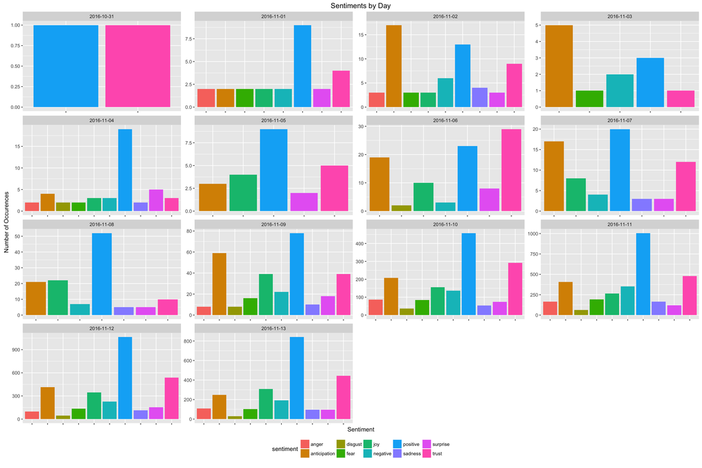

```r
gg<-ggplot(by_day_sentiment,aes(x=sentiment,y=n,fill=sentiment))
gg<-gg+geom_bar(stat="identity")
gg<-gg+facet_wrap(~day,ncol=4,scales="free")
gg<-gg+scale_x_discrete(labels=element_blank())
gg<-gg+xlab("Sentiment")+ylab("Number of Occurences")+ggtitle("Sentiments by Day")
gg<-gg+theme(legend.position="bottom")
gg
```

This is what the same graphic looks like if the scales are fixed.

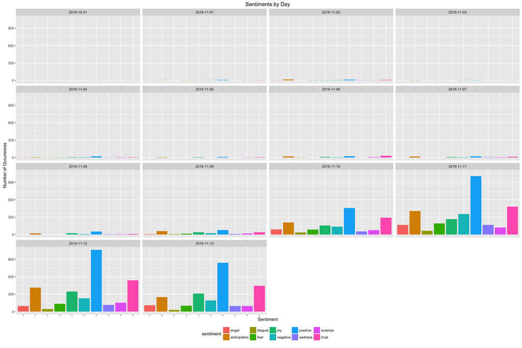

```r
gg<-ggplot(by_day_sentiment,aes(x=sentiment,y=n,fill=sentiment))
gg<-gg+geom_bar(stat="identity")
gg<-gg+facet_wrap(~day,ncol=4)
gg<-gg+scale_x_discrete(labels=element_blank())
gg<-gg+xlab("Sentiment")+ylab("Number of Occurences")+ggtitle("Sentiments by Day")
gg<-gg+theme(legend.position="bottom")
gg
```

And, how about a line plot?

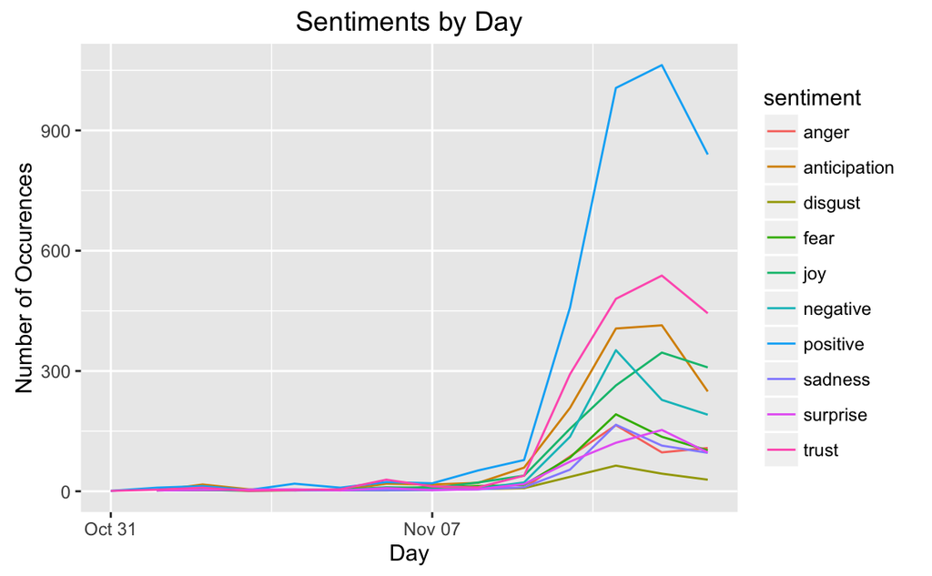

```r
gg<-ggplot(by_day_sentiment,aes(x=ymd(day),y=n,color=sentiment))
gg<-gg+geom_line()
gg<-gg+xlab("Day")+ylab("Number of Occurences")+ggtitle("Sentiments by Day")
gg
```

## What terms are trending?

We can also use these tweets to get a sense of which words were being used in tweets during the time around the conference.

This begins by creating a dataset that filters out any hash tags or individual tags.

```r
words<-by_day_common%>%filter(hash_flag==0&at_flag==0)%>%select(day,word,nn)
```

Then, subset the data to be just the top 10 words for each day.

```r
words<-words%>%group_by(day)%>%filter(nn>5)%>%mutate(word=fct_reorder(f=as.factor(word),x=nn))%>%top_n(10, nn)
words
```

| at_flag | hash_flag | day | word | nn |
| --- | --- | --- | --- | --- |
| 0 | 0 | 2016-11-11 | public | 115 |
| 0 | 0 | 2016-11-12 | students | 109 |
| 0 | 0 | 2016-11-11 | research | 105 |
| 0 | 0 | 2016-11-13 | student | 64 |
| 0 | 0 | 2016-11-13 | students | 63 |
| 0 | 0 | 2016-11-12 | ed | 62 |
| 0 | 0 | 2016-11-11 | education | 60 |
| 0 | 0 | 2016-11-12 | research | 59 |
| 0 | 0 | 2016-11-11 | college | 55 |
| 0 | 0 | 2016-11-11 | students | 53 |

[output cut: 90 more lines]

Now it’s ready to plot. Notice that the scales are different for each facet.

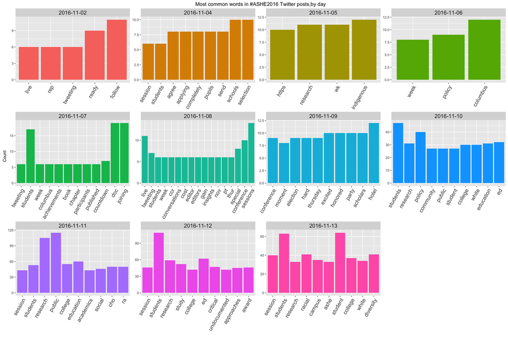

```r
gg<-ggplot(filter(words),aes(x=word, y=nn,fill=as.factor(day)))
gg<-gg+geom_bar(stat="identity")
gg<-gg+facet_wrap(~day,scales="free")
gg<-gg+theme(axis.text.x = element_text(angle = 60, hjust = 1,size=14),legend.position="none")
gg<-gg+theme(strip.text=element_text(size=14))
gg<-gg+xlab("")+ylab("Count")
gg<-gg+ggtitle("Most common words in #ASHE2016 Twitter posts,by day")
gg
```